# How to manipulate Big Data using Microsoft R Server?

Aditya

08-Mar-2017

## Overview

In this post I will demonstrate how to manipulate big data files using [Mircosoft R server](https://msdn.microsoft.com/en-us/microsoft-r/rserver) or MRS. The prerequisites to reproduce the analysis in this post will be an installation of MRS or MRC ([Microsoft R Client](https://msdn.microsoft.com/en-us/microsoft-r/r-client)) and the data files from this very popular [Kaggle competition](https://www.kaggle.com/c/talkingdata-mobile-user-demographics). This post will the first of a 2 part series. I will prepare the data in this post and use it in the subsequent post for a machine learning experiment.

## Understanding the data and the task

It is always in the best interest of any organization to know more about its customers. In this particular scenario, a certain company has all the tools to capture the mobile device usage behaviour of its customers through an SDK installed in its app. The company wants to predict the gender of its users basis this information. There are multiple benefits in accurately predicting this information. Typically gender is a [PII](https://en.wikipedia.org/wiki/Personally_identifiable_information) and users are not willing to share it readily. By predicting the gender information the companies can gain by better segmenting its users and showing more targeted ads hence bumping up the ROI considerably on the marketing campaigns.

The data has a collection of about 6 files. As we can see below few files are pretty big to fit in to the RAM hence the need to use MRS.

```r
library(dplyr)
data.frame(name = list.files(pattern = "csv"),
           size_in_MB = file.size(list.files(pattern = "csv"))/10^6) %>%
        arrange(desc(size_in_MB))
```

```
##                           name  size_in_MB
## 1               app_events.csv 1037.267659
## 2                   events.csv  195.433779
## 3               app_labels.csv   11.190003
## 4 phone_brand_device_model.csv    6.715635
## 5         gender_age_train.csv    2.366486
## 6         label_categories.csv    0.016450
```

Below is a breif description of information that is available:

**Device Brand** : Brand of the device being used by the customer

**Events** : Timestamp and geo-location of varous event recorded on the device

**App events** : List of apps involved in every event

**App categories** : Description of apps and its categories

**Gender and Age** : Gender and Age of the customer. This information will be used as label

For this experiment we will not be using the device brand as they are not available in the English language. Also, we will use the MRS’s RevoScaleR package when exploring the large files i.e. `events` and `app_events`.

## Data Preparation

The objective of this step is to collect various features for every user along with the gender information. By the end of this step we will target to capture the following information.

1. Gender
2. Age
3. Mean longitude of the user position
4. Mean latitude of the user position
5. Total number of apps used by every user
6. Weekday with maximum activity (based on total number of apps)
7. Day hour with maximum activity (based on total number of apps)

Lets start collecting our features by exploring various files.

### Step 1 & 2: Gender & Age

```r
# gender_age_train.csv
gender_age <- read.csv(file = "gender_age_train.csv", stringsAsFactors = TRUE)

# We will encode device_id to smaller number to save memory
map <- data.frame(device_id = gender_age$device_id, new_id = 1:nrow(gender_age))
gender_age <- merge(gender_age, map, by.x = "device_id", by.y = "device_id")
gender_age$device_id <- NULL

# Drop group columns as well as it is a combination of gender and age
gender_age$group <- NULL

head(gender_age)
```

```
##   gender age new_id
## 1      M  24   6247
## 2      M  36  21595
## 3      M  29  65105
## 4      M  23  71809
## 5      F  56  67366
## 6      F  27  38986
```

### Step 3, 4 & 5: Longitude, Latitude and Total number of Apps

We will use the RevoScaleR package to read `events.csv` in to an xdf file and explore the data.

```r
# Point to csv file
events <- "events.csv"
events.xdf <- "events.xdf"

# Import the csv into an xdf data source
events.xdf <- rxImport(events, events.xdf, stringsAsFactors = FALSE, overwrite = TRUE)
dim(events.xdf)[1]
```

```
## [1] 3252950
```

As we can see about 3.2M rows have been read into the xdf file. It would have been a great deal if we were to read this data to in-memory. Further, we can use various RevoScaleR functions to explore and manipulate the data.

```r
# See top 5 rows (equivalent to head in base R)
i <- rxGetInfo(events.xdf, numRows = 5, getVarInfo = TRUE)
i$data
```

```
##   event_id     device_id           timestamp longitude latitude
## 1        1  2.918269e+16 2016-05-01 00:55:25    121.38    31.24
## 2        2 -6.401643e+18 2016-05-01 00:54:12    103.65    30.97
## 3        3 -4.833982e+18 2016-05-01 00:08:05    106.60    29.70
## 4        4 -6.815121e+18 2016-05-01 00:06:40    104.27    23.28
## 5        5 -5.373798e+18 2016-05-01 00:07:18    115.88    28.66
```

We will perform the following transforms to this data:

1. Replace `device_id` with `new_id` using the `map` object we created earlier
2. Get the Year, Month, Day, Hour and Minute information from `timestamp` for each of the events

For step a., we will use the `rxMerge` function

```r
merged.xdf <- rxMerge(events.xdf,
                      map,
                      type = "inner",
                      matchVars = "device_id",
                      outFile = "merged.xdf",
                      overwrite = TRUE)

i <- rxGetInfo(merged.xdf, numRows = 5, getVarInfo = TRUE)
i$numRows
```

```
## [1] 1215595
```

The merged file has about 1.2M rows which indicates that not all `device_id` have event information. We will proceed with those devices that have the event information.

Lets move on to the next step. Adding timestamp information. We will use the `rxDataStep` function to perform the transformations and write back the changes to the same file.

```r
rxDataStep(merged.xdf, merged.xdf, overwrite = TRUE,
           transforms = list(
                   year = (as.POSIXlt(timestamp))$year,
                   month = (as.POSIXlt(timestamp))$mon,
                   day  = factor((as.POSIXlt(timestamp))$wday, levels = 0:6,
                       labels = c("Su","M","Tu", "W", "Th","F", "Sa")),
                   hr = (as.POSIXlt(timestamp))$hour,
                   min = (as.POSIXlt(timestamp))$min
           ),
           transformPackages = c("base"))

i <- rxGetInfo(merged.xdf, numRows = 5, getVarInfo = TRUE)
i$data
```

```
##   event_id     device_id           timestamp longitude latitude new_id
## 1    11281 -9.222957e+18 2016-05-07 11:36:04      0.00     0.00  21595
## 2    12679 -9.222957e+18 2016-05-07 12:18:35    113.24    23.19  21595
## 3    49383 -9.222957e+18 2016-05-07 15:44:45      0.00     0.00  21595
## 4   131849 -9.222957e+18 2016-05-07 12:06:35    113.24    23.19  21595
## 5   205471 -9.222957e+18 2016-05-06 15:36:46    113.24    23.19  21595
##   year month day hr min
## 1  116     4  Sa 11  36
## 2  116     4  Sa 12  18
## 3  116     4  Sa 15  44
## 4  116     4  Sa 12   6
## 5  116     4   F 15  36
```

Now we can drop `device_id` and `timestamp` variables.

```r
merged_new.xdf <- RxXdfData("merged_new.xdf")
rxDataStep(merged.xdf,
           merged_new.xdf,
           overwrite = TRUE,
           varsToDrop = c("device_id", "timestamp"))

i <- rxGetInfo(merged_new.xdf, numRows = 5, getVarInfo = TRUE)
i$data
```

```
##   event_id longitude latitude new_id year month day hr min
## 1    11281      0.00     0.00  21595  116     4  Sa 11  36
## 2    12679    113.24    23.19  21595  116     4  Sa 12  18
## 3    49383      0.00     0.00  21595  116     4  Sa 15  44
## 4   131849    113.24    23.19  21595  116     4  Sa 12   6
## 5   205471    113.24    23.19  21595  116     4   F 15  36
```

We will now look at some summaries on this xdf file using `rxSummary` and `rxHistogram` functions. Lets try to answer few questions to understand the data better,

1. How is the user activity spread across the week?

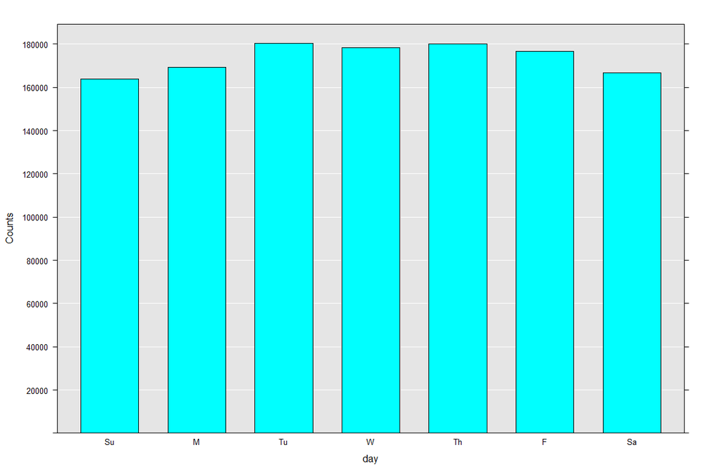

```r
rxHistogram(~ day, merged.xdf)
```

Surprisingly, the user activity is pretty uniform except for a minor bump on Tuesday and Thursday. The activity is the lowest during the weekends.

2. How is the user activity spread across the day?

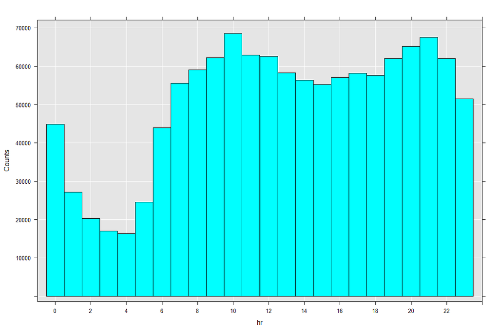

```r
rxHistogram(~ F(hr), merged_new.xdf)
```

The user activity understandably is at its peak at 10AM and 9PM while at its lowest during the early hours of the day.

We will now move to the `app_events.csv` to extact the relevant features.

```r
app_events <- "app_events.csv"
app_events.xdf <- "app_events.xdf"

# Import the csv into an xdf data source
app_events.xdf <- rxImport(app_events,
                           app_events.xdf,
                           stringsAsFactors = FALSE,
                           overwrite = TRUE)

i <- rxGetInfo(app_events.xdf, getVarInfo = TRUE, numRows = 5)
i$numRows
```

```
## [1] 32473067
```

```r
i$data
```

```
##   event_id        app_id is_installed is_active
## 1        2  5.927333e+18            1         1
## 2        2 -5.720079e+18            1         0
## 3        2 -1.633888e+18            1         0
## 4        2 -6.531843e+17            1         1
## 5        2  8.693964e+18            1         1
```

This file has about 32M rows with information about apps involved in each and every event. We will merge this information with `merged_new.xdf`.

```r
all.merged.xdf <- rxMerge(merged_new.xdf,
                          app_events.xdf,
                          outFile = "all.merged.xdf",
                          type = "inner",
                          matchVars = "event_id",
                          overwrite = TRUE,
                          varsToDrop2 = c("is_installed", "is_active"))

i <- rxGetInfo(all.merged.xdf, getVarInfo = TRUE, numRows = 5)
i$data
```

```
##   event_id longitude latitude new_id year month day hr min        app_id
## 1        6         0        0  51155  116     4  Su  0  27 -7.377004e+18
## 2        6         0        0  51155  116     4  Su  0  27  6.284165e+18
## 3        6         0        0  51155  116     4  Su  0  27  5.927333e+18
## 4        6         0        0  51155  116     4  Su  0  27  3.433290e+18
## 5        6         0        0  51155  116     4  Su  0  27 -3.467200e+18
```

We finally managed to get all the data together with 12M rows. This is where Microsoft R server shines. It would have been impossible to get to this stage if we were conducting the experiment in an R Open environment. The parallel and distributed functions of MRS allow us to work with files residing on the disk, chunk them and perform transformations chunk wise in the memory. The final xdf file which is on the disk with 12M rows is only 21MB!

We can now continue aggregating this data to device level (`new_id` in our case). To perform data aggregation we will take help of the `dplyrXdf` [package](https://github.com/RevolutionAnalytics/dplyrXdf/blob/master/vignettes/dplyrXdf_intro.Rmd).

```r
# First install the package
devtools::install_github("RevolutionAnalytics/dplyrXdf")
library(dplyrXdf)
```

We will ignore `year` and `month` as we have data for only May 2016, so that is constant across all devices.

```r
agg.xdf <- all.merged.xdf %>%
        group_by(new_id) %>%
        summarise(med_lon = mean(longitude), # Mean of Longitude
                  med_lat = mean(latitude),  # Mean of Latitude
                  num_apps = n(app_id)) %>%  # Number of Apps
                  #gender = unique(gender),
                  #age = max(age),
                  #mode_day = names(which.max(table(day))),
                  #mode_hr = names(which.max(table(F(hr))))) %>%
       persist("agg.xdf")

## Note: the dplyXdf does not provide support to arbitrary functions in summarise
# in its fastest form. Hence we will comment other variables for now and compute
# seperately.

i <- rxGetInfo(agg.xdf, getVarInfo = TRUE, numRows = 5)
i$data
```

```
##   new_id   med_lon  med_lat num_apps
## 1      3   0.00000  0.00000       53
## 2     12  76.76741 20.38272       81
## 3     14   0.00000  0.00000      154
## 4     16 120.25431 31.89642      109
## 5     19 117.23261 39.12894      303
```

### Step 6: Weekday with maximum activity (based on total number of apps)

To compute the maximum activity day for each device we perform the following steps:

1. Compute total number of apps grouped by device and day

```r
agg2.xdf <- all.merged.xdf %>%
        group_by(new_id, day) %>%
        summarise(num_apps = n(app_id)) %>%
        persist("agg2.xdf")

i <- rxGetInfo(agg2.xdf, getVarInfo = TRUE, numRows = 5)
i$data
```

```
##   new_id day num_apps
## 1      3  Su       53
## 2     16  Su       39
## 3     19  Su       99
## 4     30  Su       70
## 5     36  Su      147
```

2. Select the MAX(`num_apps`) grouped by device

```r
agg3.xdf <- agg2.xdf %>%
        group_by(new_id) %>%
        summarise(max_num_apps = max(num_apps)) %>%
        persist("agg3.xdf")

i <- rxGetInfo(agg3.xdf, getVarInfo = TRUE, numRows = 5)
i$data
```

```
##   new_id max_num_apps
## 1      3           53
## 2     12           52
## 3     14           94
## 4     16           39
## 5     19          101
```

3. Finally merge steps a & b. Compared to the capabilities of Open R this appears a bit awkward but the power lies in the parallel algorithms and spped of execution when working with big data files.

```r
top_day.xdf <- rxMerge(agg3.xdf,
                       agg2.xdf,
                       outFile = "top_day.xdf",
                       type = "inner",
                       matchVars = c("new_id", "max_num_apps"),
                       overwrite = TRUE,
                       newVarNames2 = c(num_apps = "max_num_apps"))

# Select the first day in case there is a tie between 2 days.
# We can as well select last day

rxSort(inData = top_day.xdf,
       outFile = top_day.xdf,
       sortByVars = "new_id",
       removeDupKeys = TRUE,
       overwrite = TRUE)

i <- rxGetInfo(top_day.xdf, getVarInfo = TRUE, numRows = 5)
i$data
```

```
##   new_id max_num_apps day
## 1      3           53  Su
## 2     12           52   W
## 3     14           94  Th
## 4     16           39  Su
## 5     19          101   F
```

### Step 7: Day hour with maximum activity (based on total number of apps)

We will repeat the similar process to get the maximum activity hour for each device.

```r
agg4.xdf <- all.merged.xdf %>%
        group_by(new_id, hr) %>%
        summarise(num_apps = n(app_id)) %>%
        persist("agg4.xdf")

agg5.xdf <- agg4.xdf %>%
        group_by(new_id) %>%
        summarise(max_num_apps = max(num_apps)) %>%
        persist("agg5.xdf")

top_hr.xdf <- rxMerge(agg5.xdf, agg4.xdf, outFile = "top_hr.xdf", type = "inner",
                        matchVars = c("new_id", "max_num_apps"),
                        overwrite = TRUE,
                        newVarNames2 = c(num_apps = "max_num_apps"))

# Select the first hour in case there is a tie between 2 different hours. We can as well select last hour.

rxSort(inData = top_hr.xdf,
       outFile = top_hr.xdf,
       sortByVars = "new_id",
       removeDupKeys = TRUE,
       overwrite = TRUE)

i <- rxGetInfo(top_hr.xdf, getVarInfo = TRUE, numRows = 5)
i$data
```

```
##   new_id max_num_apps hr
## 1      3           53 14
## 2     12           52 14
## 3     14           40 22
## 4     16           46 12
## 5     19          103 17
```

Finally, merging `top_day.xdf` and `top_hr.xdf` with `agg.xdf` to bring all features together

```r
allfeat.xdf <- rxMerge(agg.xdf,
                       top_day.xdf,
                       outFile = "allfeat.xdf",
                       matchVars = "new_id",
                       type = "inner",
                       overwrite = TRUE
                       #varsToDrop2 = "max_num_apps",
                       #newVarNames2 = c(day = "top_day")
                      )

allfeat.xdf <- rxMerge(allfeat.xdf,
                       top_hr.xdf,
                       outFile = "allfeat.xdf",
                       matchVars = "new_id",
                       type = "inner",
                       overwrite = TRUE
                       #varsToDrop2 = "max_num_apps",
                       #newVarNames2 = c(hr = "top_hr")
                       )
i <- rxGetInfo(allfeat.xdf, getVarInfo = TRUE, numRows = 5)
i$data
```

```
##   new_id   med_lon  med_lat num_apps max_num_apps.allfeat day
## 1      3   0.00000  0.00000       53                   53  Su
## 2     12  76.76741 20.38272       81                   52   W
## 3     14   0.00000  0.00000      154                   94  Th
## 4     16 120.25431 31.89642      109                   39  Su
## 5     19 117.23261 39.12894      303                  101   F
##   max_num_apps.top_hr hr
## 1                  53 14
## 2                  52 14
## 3                  40 22
## 4                  46 12
## 5                 103 17
```

To conclude the feature engineering process we will map this information with demographic information and remove certain redundant columns.

```r
allfeat.xdf <- rxMerge(gender_age,
                       allfeat.xdf,
                       outFile = "allfeat.xdf",
                       matchVars = "new_id",
                       type = "inner",
                       overwrite = TRUE,
                       varsToDrop2 = c("max_num_apps.allfeat", "max_num_apps.top_hr")
                       )
i <- rxGetInfo(allfeat.xdf, getVarInfo = TRUE, numRows = 5)
i$data
```

```
##   gender age new_id   med_lon  med_lat num_apps day hr
## 1      M  35      3   0.00000  0.00000       53  Su 14
## 2      F  37     12  76.76741 20.38272       81   W 14
## 3      M  32     14   0.00000  0.00000      154  Th 22
## 4      F  28     16 120.25431 31.89642      109  Su 12
## 5      M  75     19 117.23261 39.12894      303   F 17
```

Note that we are ignoring the devices which do not have the app events related information.

We managed to get the data in to a good shape to explore if there is any relationship between the gender and max activity day and max activity hour.

Before we do that we need to convert the `hr` variable to factor as well.

```r
allfeat.xdf <- rxFactors(allfeat.xdf,
                         factorInfo = list(
                                 hr = list(levels = 0:23,
                                         newLevels = c( `0` = "0", `1` = "1",
                                                        `2` = "2", `3` = "3",
                                                        `4` = "4", `5` = "5",
                                                        `6` = "6", `7` = "7",
                                                        `8` = "8", `9` = "9",
                                                        `10` = "10", `11` = "11",
                                                        `12` = "12", `13` = "13",
                                                        `14` = "14", `15` = "15",
                                                        `16` = "16", `17` = "17",
                                                        `18` = "18", `19` = "19",
                                                        `20` = "20", `21` = "21",
                                                        `22` = "22", `23` = "23")
                                 )),
                         overwrite = TRUE
                         )

i <- rxGetInfo(allfeat.xdf, getVarInfo = TRUE, numRows = 5)
i$varInfo
```

```
## Var 1: gender
##        2 factor levels: F M
## Var 2: age, Type: integer, Low/High: (11, 89)
## Var 3: new_id, Type: integer, Low/High: (3, 74645)
## Var 4: med_lon, Type: numeric, Low/High: (-169.4634, 136.1350)
## Var 5: med_lat, Type: numeric, Low/High: (-20.3239, 50.2403)
## Var 6: num_apps, Type: numeric, Low/High: (1.0000, 48132.0000)
## Var 7: day
##        7 factor levels: Su M Tu W Th F Sa
## Var 8: hr
##        24 factor levels: 0 1 2 3 4 ... 19 20 21 22 23
```

## Data Exploration

Now that we have created new features, we can perform statistical test to ascertain the relation between the labels and independant variables (max activity day and hour).

### Gender Vs Max Activity Day

Since both these variables are factors We can quickly perform a [Chi-Squared](https://en.wikipedia.org/wiki/Chi-squared_test) to acces the good of fit.

```r
ch1 <- rxCrossTabs(~ gender : day, data = allfeat.xdf)
rxChiSquaredTest(ch1)
```

```
## Chi-squared test of independence between gender and day
##  X-squared df   p-value
##   3.126907  6 0.7927584
```

The p-value is quite high for the relationship to be significant.

### Gender Vs Max Activity Hour

We will perform the similar test between these 2 variables.

```r
ch2 <- rxCrossTabs(~ gender : hr, data = allfeat.xdf)
rxChiSquaredTest(ch2)
```

```
## Chi-squared test of independence between gender and hr
##  X-squared df      p-value
##   162.7507 23 5.045395e-23
```

The low p-value indicates that the relationship is very strong and maximum activity hour can be a good predictor for the gender.

### Gender Vs Age

Here Gender is a factor while Age is continuous variable. We can perform [t test](https://en.wikipedia.org/wiki/Student%27s_t-test) using the base R;s `t.test` function. But to perform this test we need to import the data from xdf to data frame object as RevoScaleR does not offer t-test function yet. We will write a helper function for that.

```
##
##  Welch Two Sample t-test
##
## data:  age by gender
## t = 4.4002, df = 15029, p-value = 1.089e-05
## alternative hypothesis: true difference in means is not equal to 0
## 95 percent confidence interval:
##  0.3413012 0.8896352
## sample estimates:
## mean in group F mean in group M
##        32.63179        32.01633
```

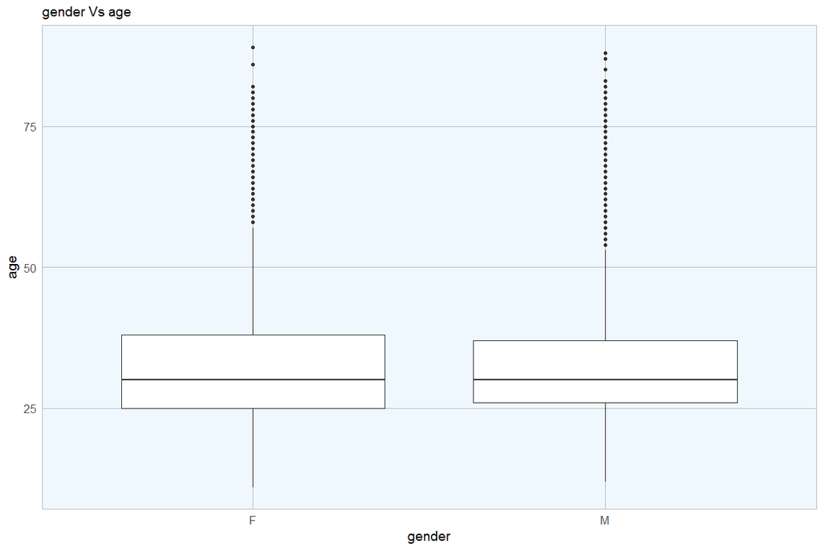

```r
test <- function(var) {
        df <- rxImport(allfeat.xdf, varsToKeep = c(var, "gender"))
        print(t.test(as.formula(paste(var, "~", "gender")), data = df))
        library(ggplot2)
        df %>% ggplot(aes_string(x = "gender", y = var)) +
                geom_boxplot() +
                my_theme() +
                labs(title = paste("gender Vs", var))
}

test("age")
```

Again the p-value is quite low indicating age can be a good indicator to predict gender.

## Next Step

In the following post we will start with this tidy data to build and evaluate various models to predict the gender. Please do leave a comment below or reach out to me for any query or if you find a bug. I will be happy to look into it.